# WasteWater Analysis 2.0

Steve Goldstein and Marlin Lee

Due to the large variations of the N1 concentration we have tried to create a smoothed version of the data set that captures the underlying shifts of the data. Below is our best attempt at smoothing the N1 concentration data. It shows relation to case data given the spread of shedding of N1. This relationship holds for N2 as well.

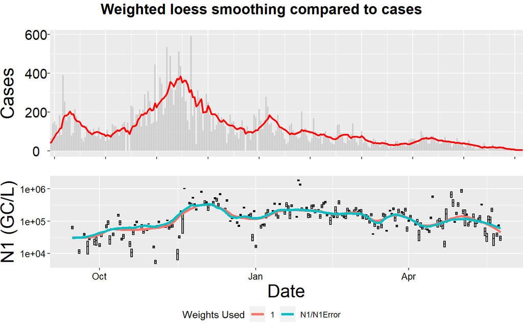

To use standard Error measurements in our smoothing we needed to have it be an unbiased estimate given the concentration. A strong correlation between N1 and N1Error means it needs to be controlled for. Using standard error normalized by N1 gave a meaningful measurement of the consistency of the data.

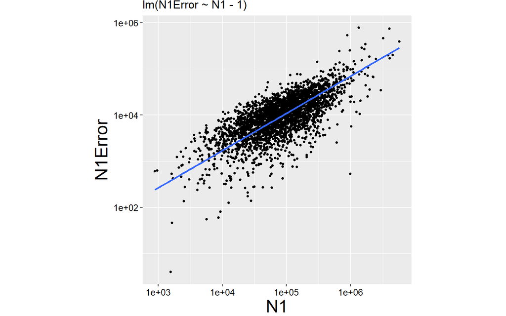

Below are the two versions of the smoothed data capturing different scales of its variations. The boxes are the concentration measured plus or minus the standard error. This gives some measure of how weighted the point is given.

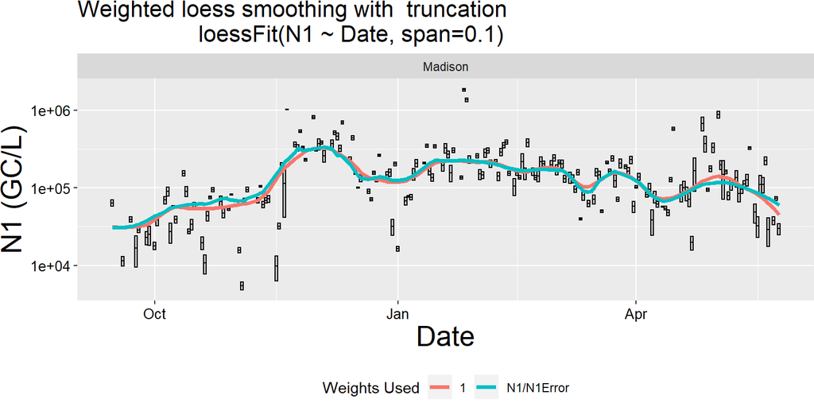

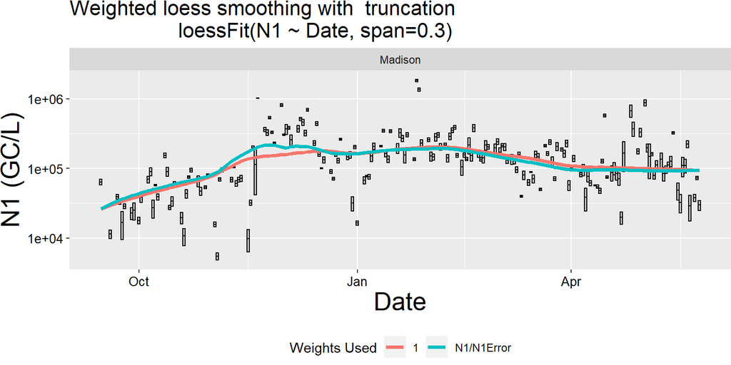

This is method is extended for the interceptors.

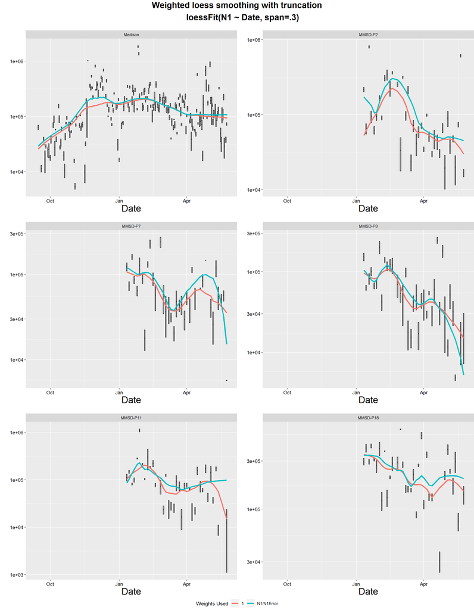

Also extended to UW data

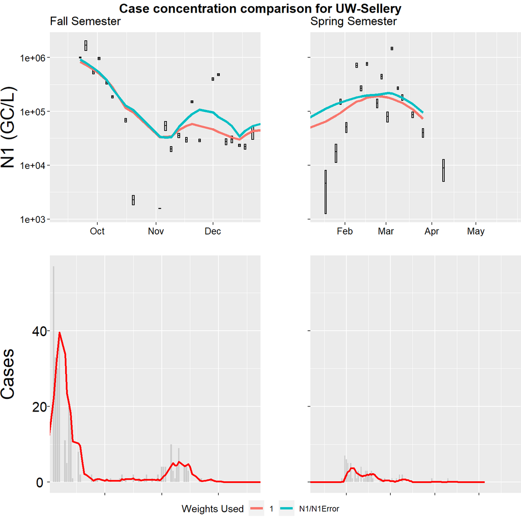

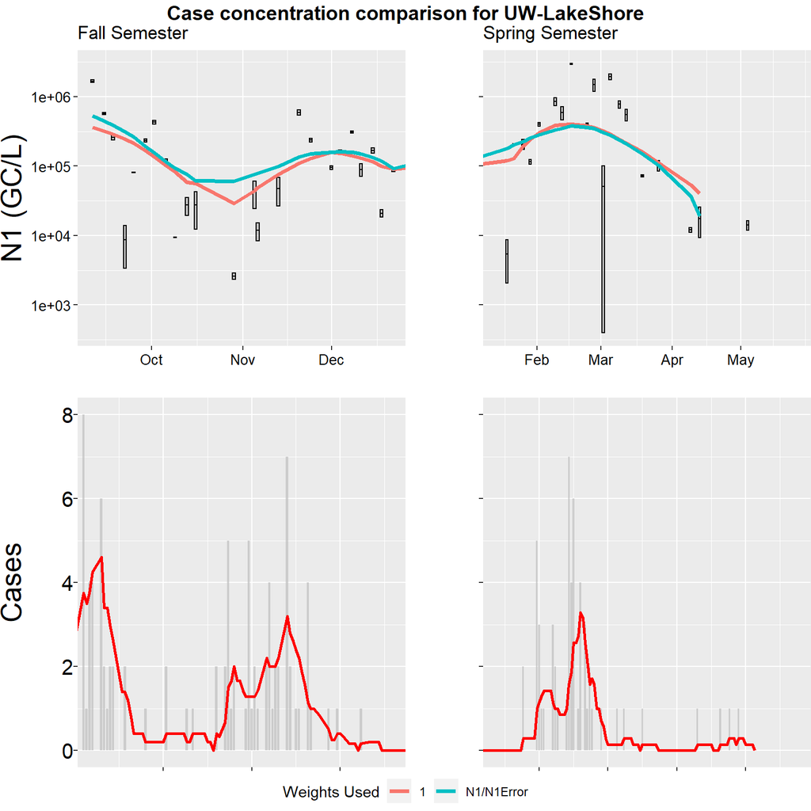

No clear use for %BCov and PMMOV. Below shows that unusual PMMoV and BCoV do not seem to relate to unusual N1 values.

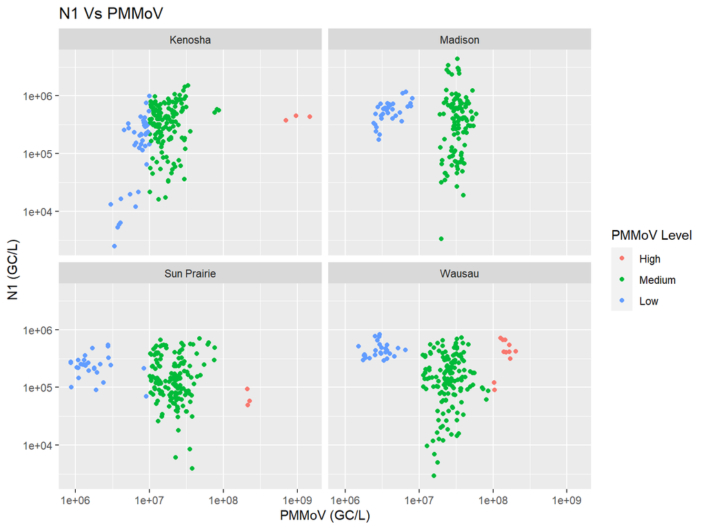

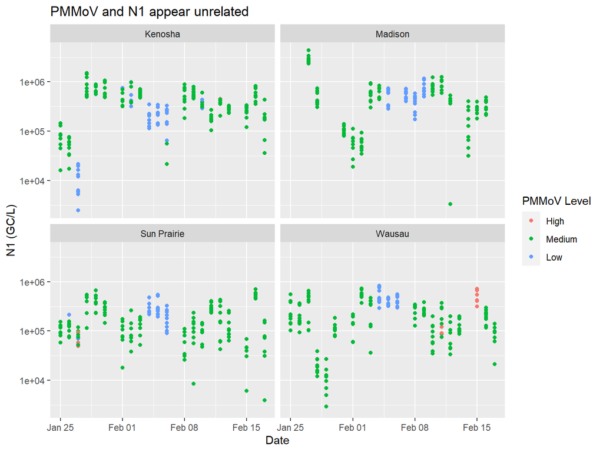

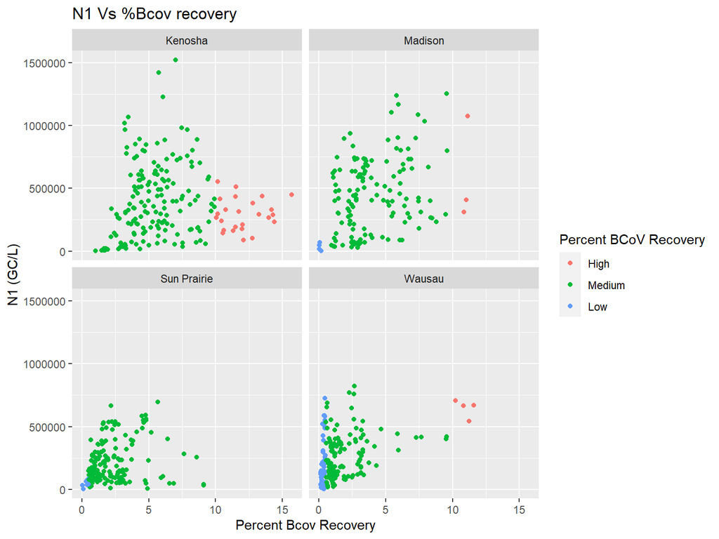

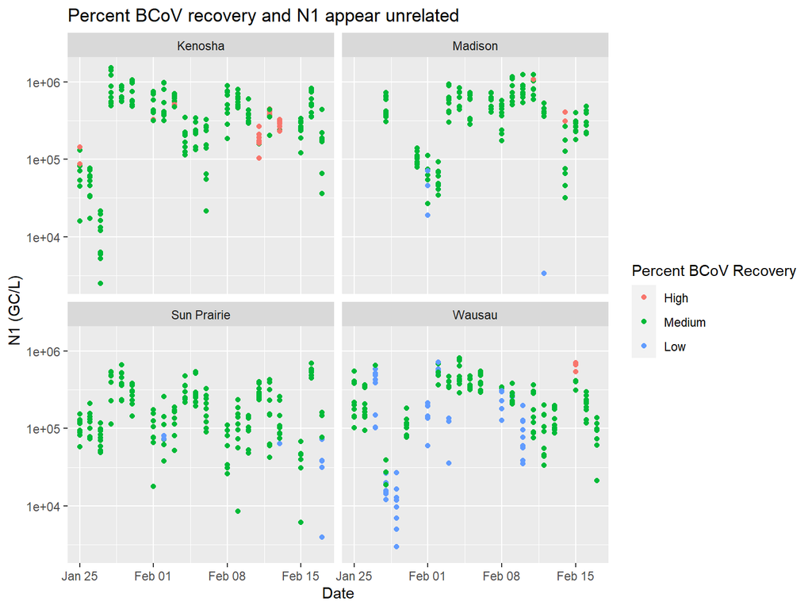